# FFXI Synthetic

Eiichi Tsuji

2018年3月12日

## 合成を考える

最初に、データを読み込む。 とりあえずは、固定しておこう。

```r
bd <- getwd()
#Cooking data of caerae
ckg <- readRDS(paste(bd, "data/caec.rds", sep='/'))
#Leathercraft data of caera
lth <- readRDS(paste(bd, "data/cael.rds", sep='/'))
#Leatthercraft data of Primasynth
plh <- readRDS(paste(bd, "data/pril.rds", sep='/'))
#Clothcraft data of Primasynth
plc <- readRDS(paste(bd, "data/pric.rds", sep='/'))
```

## レンジを考える

合成は、合成に成功をしたりしたときに、スキルアップして、0.2上がった、2になった というような表示がでる。

合成を行ったときには、その前のスキルのハズ。

したがって、データのスキル表示を一つ下にずらす必要があると思われる。

これは、テーブごとにやらないと面倒か

```r
ckg$tskill <- c(ckg$skill[1], ckg$skill)[-(length(ckg$skill))]
lth$tskill <- c(lth$skill[1], lth$skill)[-(length(lth$skill))]
plh$tskill <- c(plh$skill[1], plh$skill)[-(length(plh$skill))]
plc$tskill <- c(plc$skill[1], plc$skill)[-(length(plc$skill))]



#合成データを全部いれたやつ
synth.table <- rbind(ckg, lth, plh, plc)

#スキルギャップを計算し直し


synth.table$skill.gap <- synth.table$tskill - synth.table$target.cap
```

## 合成の成功率をスキルギャップでみる

まずは、スキルギャップをfloorで分けて表示

```r
synth.table %>%
  mutate(sr=floor(skill.gap)) %>%
  group_by(sr) %>%
  summarise(success=sum(result), try=n()) %>%
  mutate(prb=round(success/try, 3))
```

```
## # A tibble: 23 x 4
##       sr success   try    prb
##    <dbl>   <int> <int>  <dbl>
##  1  -12.       0     4 0.
##  2  -10.       2    40 0.0500
##  3   -9.       8    21 0.381
##  4   -8.      12    36 0.333
##  5   -7.       8    22 0.364
##  6   -6.      10    20 0.500
##  7   -5.      10    20 0.500
##  8   -4.      13    22 0.591
##  9   -3.      16    19 0.842
## 10   -2.      33    38 0.868
## # ... with 13 more rows
```

srをfactorにしてグラフを書いてみよう

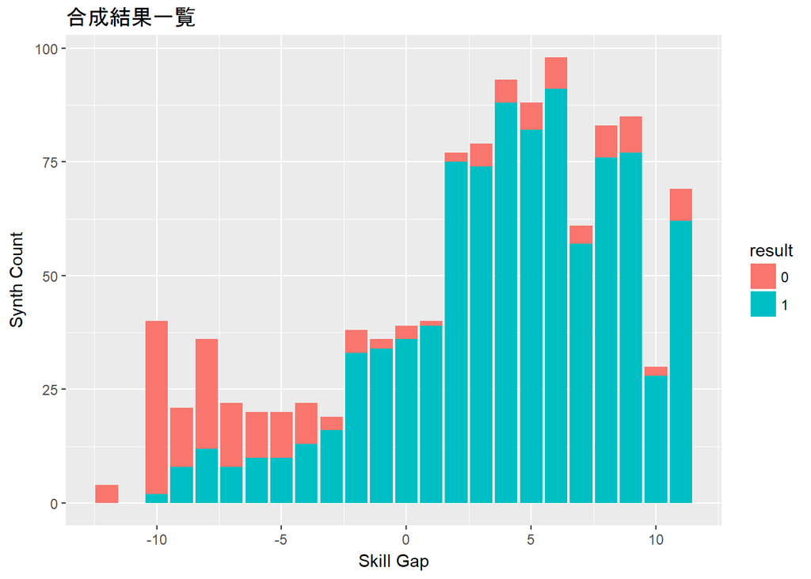

```r
synth.table %>%
  mutate(sr=floor(skill.gap)) %>%
  ggplot(aes(x=sr, fill=as.factor(result))) +
  geom_bar() +
  labs(
    x="Skill Gap",
    y="Synth Count",
    fill="result",
    title="合成結果一覧"
  )
```

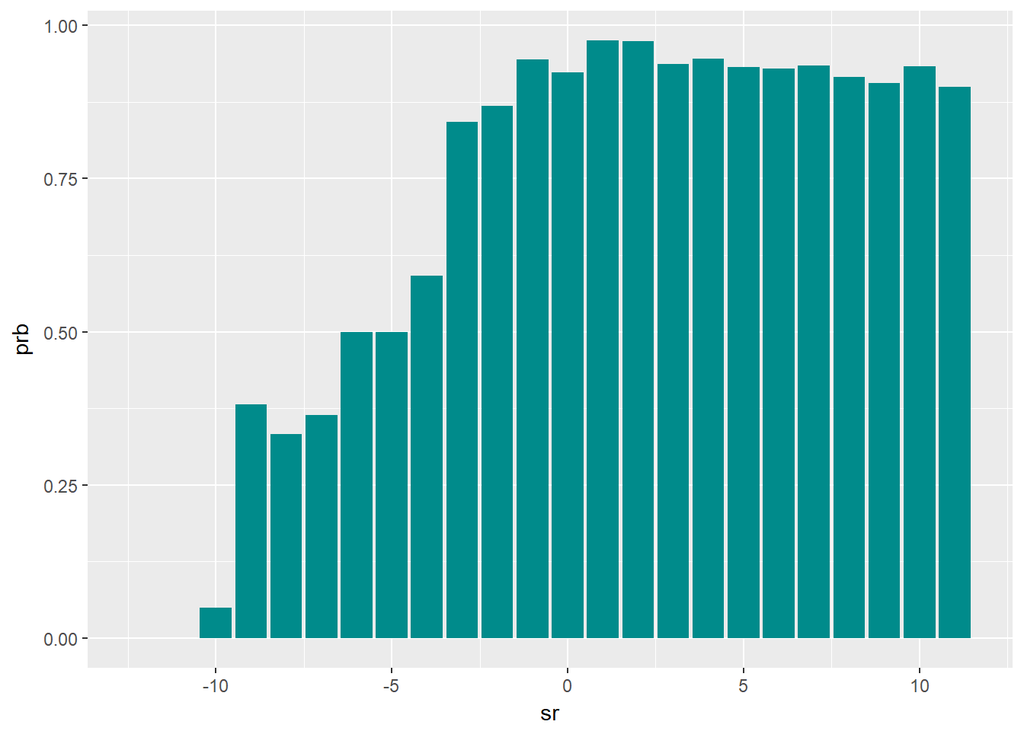

```r
synth.table %>%
  mutate(sr=floor(skill.gap)) %>%
  group_by(sr) %>%
  summarise(success=sum(result), try=n()) %>%
  mutate(prb=round(success/try, 3)) %>%
  ggplot(aes(x=sr,y=prb)) +
  geom_bar(stat="identity", fill="cyan4")
```

ここで、まずは合成成功率を分けるために、スキルギャップをランク分けする関数をつくる。

-27より小さい（合成をしようという対象のスキルキャップから、自分の現在のスキルを引いたあたい。 つまり、全然足りない場合は、座れない）

disable

-10から-27の範囲だと、もしかすると成功するかもというレベル

oneChance

-5から-10だと、結構失敗する

difficult

-3から-5だと、それなりに失敗する

risky

-2から-3だと、かなり成功する

challenge

-2以上だと、成功率はキャップとしてみる

cap

こいつを分ける関数をつくっておく

synthProb

で、ラベルをfactorで pr.label

```r
synthProb <- function(gap){

  ifelse(gap < -27, 1,
    ifelse(gap >=-27 & gap < -10, 2,
      ifelse(gap >= -10 & gap < -5, 3,
        ifelse(gap >= -5 & gap < -3, 4,
          ifelse(gap >= -3 & gap < -2, 5, 6)))))
}

pr.label <- factor(c("disable", "oneChance", "difficult", "risky", "challenge", "cap"),
                   levels = c("disable", "oneChance", "difficult", "risky", "challenge", "cap"))
```

全部のデータに関して、想定される確率の階級で分けてみると。

```r
synth.table %>%
  mutate(prob.range=pr.label[synthProb(skill.gap)]) %>%
  select(-lost, -target, -player, -Synth) %>%
  group_by(prob.range) %>%
  summarise(success=sum(result), try=n()) %>%
  mutate(prob=round(success/try, 3))
```

```
## # A tibble: 5 x 4
##   prob.range success   try  prob
##   <fct>        <int> <int> <dbl>
## 1 oneChance        0     4 0.
## 2 difficult       40   139 0.288
## 3 risky           23    42 0.548
## 4 challenge       16    19 0.842
## 5 cap            852   916 0.930
```

となる。challengeの階級は、幅が狭いのと、スキルアップが速いので、 サンプル数を稼ぐのは難しいか。

スキルを整数値でみて、それぞれの成功確率を考えてみる。

```r
skt <-
synth.table %>%
  group_by(gap=floor(skill.gap)) %>%
  summarise(success=sum(result), try=n()) %>%
  mutate(prob=round(success/try,3))

skt
```

```
## # A tibble: 23 x 4
##      gap success   try   prob
##    <dbl>   <int> <int>  <dbl>
##  1  -12.       0     4 0.
##  2  -10.       2    40 0.0500
##  3   -9.       8    21 0.381
##  4   -8.      12    36 0.333
##  5   -7.       8    22 0.364
##  6   -6.      10    20 0.500
##  7   -5.      10    20 0.500
##  8   -4.      13    22 0.591
##  9   -3.      16    19 0.842
## 10   -2.      33    38 0.868
## # ... with 13 more rows
```

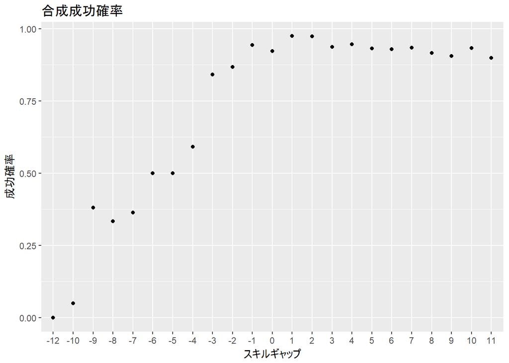

```r
ggplot(skt, aes(x=as.factor(gap),y=prob)) +
  geom_point() +
  labs(
    y="成功確率",
    x="スキルギャップ",
    title="合成成功確率"
  )
```

スキルアップに関して

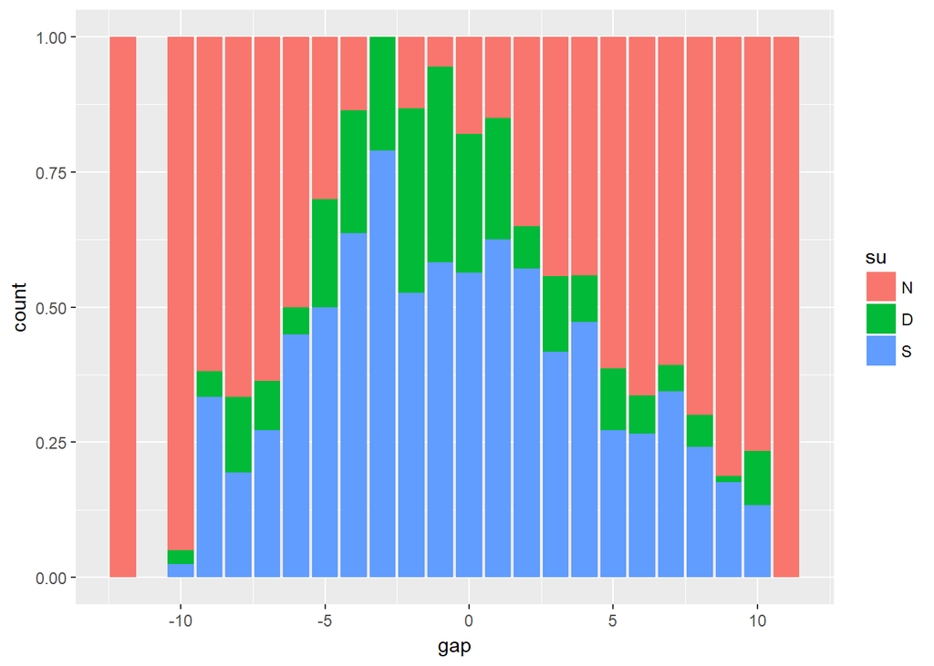

```r
suf <- function(v){
  ifelse(is.na(v), 'N', ifelse(v==0.1, 'S', 'D'))
}


synth.table %>%
  group_by(gap=floor(skill.gap), skill.up) %>%
  summarise(count=n()) %>%
  mutate(su=suf(skill.up)) %>%
  mutate(su=factor(su, levels=c("N", "D", "S"))) %>%
  ggplot(aes(x=gap,y=count, fill=su)) +
  geom_bar(stat="identity", position = "fill")
```

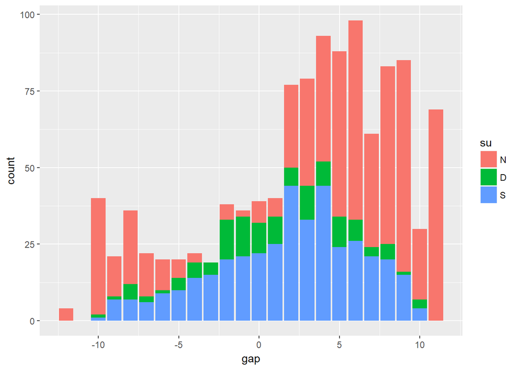

```r
synth.table %>%
  group_by(gap=floor(skill.gap), skill.up) %>%
  summarise(count=n()) %>%
  mutate(su=suf(skill.up)) %>%
  mutate(su=factor(su, levels=c("N", "D", "S"))) %>%
  ggplot(aes(x=gap,y=count, fill=su)) +
  geom_bar(stat="identity")
```

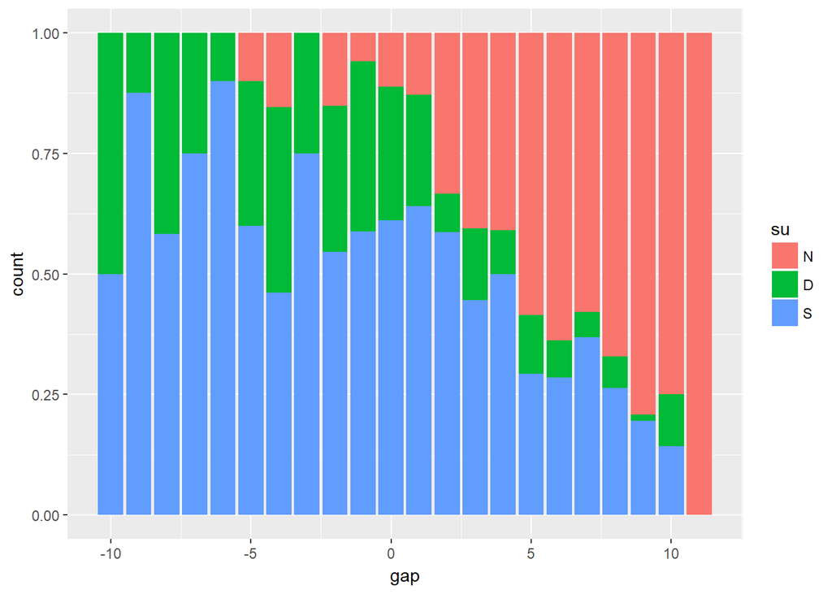

```r
synth.table %>%
  group_by(gap=floor(skill.gap), skill.up) %>%
  filter(result==1) %>%
  summarise(count=n()) %>%
  mutate(su=suf(skill.up)) %>%
  mutate(su=factor(su, levels=c("N", "D", "S"))) %>%
  ggplot(aes(x=gap,y=count, fill=su)) +
  geom_bar(stat="identity", position = "fill")
```

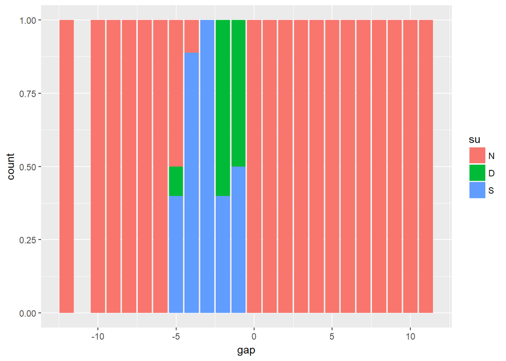

```r
synth.table %>%
  group_by(gap=floor(skill.gap), skill.up) %>%
  filter(result==0) %>%
  summarise(count=n()) %>%
  mutate(su=suf(skill.up)) %>%
  mutate(su=factor(su, levels=c("N", "D", "S"))) %>%
  ggplot(aes(x=gap,y=count, fill=su)) +
  geom_bar(stat="identity", position = "fill")
```